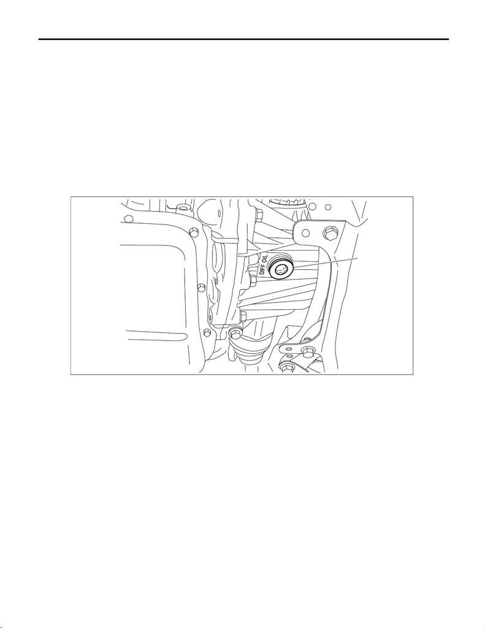

CVT(TR690)-89

Differential Side Retainer Oil Seal

CONTINUOUSLY VARIABLE TRANSMISSION

13.Differential Side Retainer Oil Seal

A: INSPECTION

Check for leakage of gear oil from differential side retainer oil seal part. If there is an oil leak, inspect the front

drive shaft and replace the oil seal.

B: REPLACEMENT

CAUTION:

• Immediately after the vehicle has been running or after idling for a long time, the differential gear

oil will be hot. Be careful not to burn yourself.

• Be careful not to spill the differential gear oil on exhaust pipe to prevent it from emitting smoke or

fire. If differential gear oil is spilled on the exhaust pipe, wipe it off completely.

1) Remove the front wheels.

2) Remove the center exhaust pipe (rear). <Ref. to EX(w/o STI)-35, REMOVAL, Center Exhaust Pipe.>

3) Remove the differential gear oil drain plug using TORX

®

bit T70, and then drain differential gear oil.

4) Tighten the differential gear oil drain plug.

NOTE:

Use a new gasket.

Tightening torque:

70 N·m (7.1 kgf-m, 51.6 ft-lb)

5) Remove the stabilizer link. <Ref. to FS-31, REMOVAL, Front Stabilizer.>

6) Disconnect the lower arm ball joint and housing.

NOTE:

side retainer.

8) Holding the joint of front drive shaft from transmission side, pull out the drive shaft from transmission with

care not to stretch the boot.

NOTE:

• Before pulling RH front drive shaft from transmission, turn the steering wheel to left hand full lock.

• Before pulling LH front drive shaft from transmission, turn the steering wheel to right hand full lock.

9) Remove the differential side retainer oil seal using driver wrapped with vinyl tape etc.

(A) Differential gear oil drain plug

(A)

AT-07751

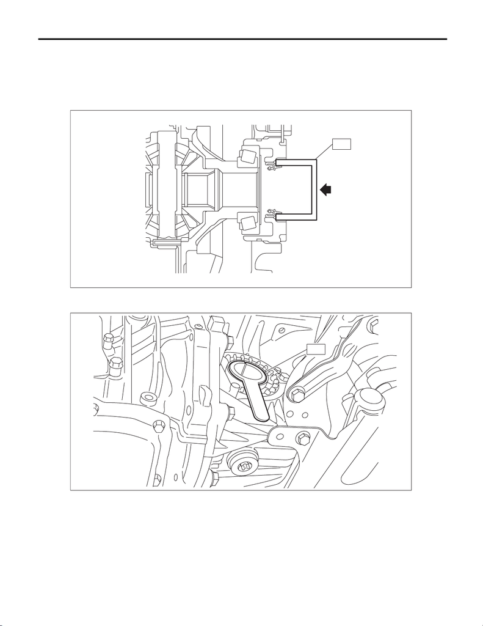

CVT(TR690)-90

Differential Side Retainer Oil Seal

CONTINUOUSLY VARIABLE TRANSMISSION

10) Using the ST, install the differential side retainer oil seal by lightly tapping with a hammer.

ST 18675AA000 DIFFERENTIAL SIDE OIL SEAL INSTALLER

NOTE:

• Apply differential gear oil to the lip surface, so that the oil seal lip is not deformed.

• Apply differential gear oil to the press-fitting surface of oil seal and the differential side retainer.

• Oil seal has an identification mark (R, L). When installing oil seals, do not confuse the left and right.

11) Set the ST to side retainer.

ST 28399SA010 OIL SEAL PROTECTOR

AT-05142

ST

AT-07746

ST

[figure not shown]

CVT(TR690)-91

Differential Side Retainer Oil Seal

CONTINUOUSLY VARIABLE TRANSMISSION

12) Replace the circlip of the drive shaft with a new part.

13) Insert the front drive shaft spline section into transmission and remove the ST (OIL SEAL PROTECTOR).

14) Insert the drive shaft into the transmission securely by pressing the housing from outside of the vehicle.

15) Insert the ball joint into housing and secure with bolt.

Tightening torque:

50 N·m (5.1 kgf-m, 36.9 ft-lb)

CAUTION:

• Do not apply grease to the tapered portion of ball stud.

• Before tightening, make sure the lower side of housing and stepped section of ball joint are in con-

tact.

16) Install the stabilizer link.

Tightening torque:

60 N·m (6.1 kgf-m, 44.3 ft-lb)

17) Install the center exhaust pipe (rear). <Ref. to EX(w/o STI)-41, INSTALLATION, Center Exhaust Pipe.>

18) Lower the vehicle.

19) Refill differential gear oil from the charge pipe. <Ref. to CVT(TR690)-41, Differential Gear Oil.>

20) Adjust the differential gear oil level, and check for leakage. <Ref. to CVT(TR690)-41, ADJUSTMENT, Dif-

ferential Gear Oil.>

21) Install the front tires.